# Regional Disparities in Rehabilitation Provision and Hip Fracture Surgery Rates Among Older Adults in Japan: A Nationwide Ecological Study

Authors

Affiliations

[Author 1]

[Affiliation 1]

[Author 2]

[Affiliation 2]

Published

April 15, 2026

# 1 Abstract

**Background:** Regional disparities in rehabilitation provision are well documented in Japan, yet their ecological association with hip fracture surgery rates remains unclear. We examined whether prefecture-level rehabilitation claim rates (H000–H004) were associated with hip fracture surgery rates among older adults using nationwide open data.

**Methods:** Cross-sectional ecological study of Japan’s 47 prefectures. Rehabilitation claim rates (total; disuse-syndrome rehabilitation, H002; musculoskeletal rehabilitation, H003) per 100,000 population were derived from NDB Open Data No.10 (FY2023). Hip fracture surgery rates (K044/K045/K046/K081/K082 with femoral site codes, per 100,000) were derived from the same database. Covariates included aging rate and population density from the 2020 Census. Ordinary least squares (OLS) regression with six pre-specified sensitivity specifications was applied. Spatial autocorrelation was assessed with Global Moran’s I, and Lagrange Multiplier (LM) tests guided selection of spatial econometric models (Spatial Lag Model and Spatial Error Model).

**Results:** Mean rehabilitation total claim rate was 88,389 (SD 35,945) per 100,000, ranging 6.8-fold across prefectures (Iwate 27,183 to Kagoshima 183,490). Mean hip fracture surgery rate was 254.0 (SD 37.6) per 100,000. In OLS models, rehabilitation total rate was positively associated with hip fracture rate (β = 0.0005; p < 0.001; R² = 0.51; 6/6 sensitivity specifications significant). Both variables exhibited strong spatial autocorrelation (Moran’s I > 0.54, p = 0.001). LM tests identified spatial error dependence (LM-error p < 0.001; RLM-error p = 0.003). The Spatial Error Model (SEM) fit substantially better than OLS (ΔAIC = −16.6) with a significant spatial error parameter (λ = 0.671, p < 0.001); in the SEM, the rehabilitation coefficient was non-significant (β = 0.000164, p = 0.130).

**Conclusions:** The positive OLS association between rehabilitation provision and hip fracture surgery rates was substantially explained by spatially structured geographic confounding, as evidenced by the non-significant SEM coefficient. The 6.8-fold variation in rehabilitation claim rates across prefectures nonetheless documents profound regional disparities in access that warrant policy attention.

**Keywords:** rehabilitation; hip fracture; regional disparities; ecological study; Japan; NDB Open Data; spatial autocorrelation

# 2 Introduction

Hip fracture is a major cause of disability, institutionalization, and excess mortality among older adults worldwide (1–3) and in Japan, where incidence rates are among the highest in Asia (4–6). Post-fracture functional recovery is strongly influenced by timely and intensive rehabilitation (7,8), and clinical guidelines universally recommend early mobilization and multidisciplinary rehabilitation programs following hip fracture surgery.

Japan’s National Health Insurance system (9,10) covers five categories of inpatient rehabilitation (H000–H004 under the medical fee schedule): cardiac and vascular, cerebrovascular, disuse syndrome, musculoskeletal, and pulmonary rehabilitation. Despite universal coverage, substantial regional disparities exist in the provision of rehabilitation services, both in volume and quality (11,12). Prior research has documented geographic variation in healthcare utilization generally (13,14) and in rehabilitation provision specifically (15,16), but the ecological association between rehabilitation provision and fracture-related outcomes at the prefecture level has not been formally assessed.

We hypothesized (H1) that prefectures with higher rehabilitation claim rates would show lower hip fracture surgery rates—reflecting a preventive benefit of rehabilitation on fall prevention and physical function—and (H2) that disuse-syndrome rehabilitation (H002) would specifically show this inverse association, given its direct clinical relevance to fracture recovery and secondary prevention. We tested these hypotheses using NDB Open Data No.10 (FY2023), the largest claims-based dataset available for ecological analysis in Japan.

# 3 Methods

## 3.1 Study Design and Setting

Cross-sectional ecological study at the 47-prefecture level in Japan. The unit of analysis was the prefecture (N = 47). Data were drawn from NDB Open Data No.10 (17,18), covering fee-for-service claims from April 2023 to March 2024 (FY2023), and the 2020 Population Census.

## 3.2 Exposure Variables

Rehabilitation claim data were extracted from the NDB Open Data No.10 “H_リハビリテーション 都道府県別算定回数／単位数” (prefectural rehabilitation claim counts). Five rehabilitation categories were extracted:

- **H000**: Cardiac and vascular rehabilitation
- **H001**: Cerebrovascular and other neurological rehabilitation
- **H002**: Disuse syndrome rehabilitation *(primary exposure of interest)*
- **H003**: Musculoskeletal rehabilitation *(primary exposure of interest)*
- **H004**: Pulmonary rehabilitation

Three exposure variables were defined: (1) rehabilitation total claim rate (sum of H000–H004 per 100,000 population), (2) H002 claim rate (disuse syndrome, per 100,000), and (3) H003 claim rate (musculoskeletal, per 100,000).

## 3.3 Outcome Variables

Hip fracture surgery rates were derived from NDB Open Data No.10 surgical procedure data, extracted in a prior study (NDB_XXX_slope_fracture). Femoral fracture surgery procedures included: K044 (bone fragment removal), K045 (internal fixation), K046 (closed reduction with internal fixation), K081 (femoral head replacement: hemiarthroplasty), and K082 (total hip arthroplasty: THA). Primary outcome was the aggregate hip fracture surgery rate per 100,000 total population. Secondary outcomes included THA-specific (K082) and hemiarthroplasty-specific (K081) rates.

## 3.4 Covariates

Two a priori confounders were included: (1) aging rate (proportion aged ≥65 years, 2020 Census (19)) and (2) population density (persons per km², 2020 Census). Aging rate is the strongest predictor of both rehabilitation utilization and fracture incidence, and population density captures healthcare access and urbanicity.

## 3.5 Statistical Analysis

**Descriptive statistics:** Means, standard deviations, and ranges were calculated for all variables.

**Correlation analysis:** Pearson correlation coefficients (r) between key variable pairs were calculated.

**Primary regression:** Ordinary least squares (OLS) regression of each outcome on each exposure, adjusting for aging rate and population density (Spec1 baseline).

**Sensitivity analyses (six pre-specified specifications):**

| Specification | Description |
| --- | --- |
| Spec1 | Baseline OLS (aging_rate + pop_density) |
| Spec2 | HC3 heteroskedasticity-robust standard errors (20) |
| Spec3 | Outlier exclusion (residuals ±3 IQR) |
| Spec4 | Metropolitan exclusion (Tokyo, Osaka, Aichi, Kanagawa, Saitama, Chiba; N = 41) |
| Spec5 | Log-transformed exposure and outcome |
| Spec6 | Aging rate only as covariate |

**Variance inflation factors (VIF)** were calculated for all models. All VIF values were < 2.0, indicating no multicollinearity.

**Spatial autocorrelation:** Global Moran’s I was calculated for rehabilitation total rate and hip fracture rate using the Queen contiguity spatial weight matrix (libpysal; transformed to row-standardized) (21,22). Statistical significance was assessed by 999-permutation conditional randomization.

All analyses were performed in Python 3.14 using pandas, statsmodels, scipy, geopandas, libpysal, and esda. Statistical significance was defined as p < 0.05 (two-sided). Confidence intervals are 95%.

# 4 Results

## 4.1 Descriptive Statistics

**Table 1** summarizes the key variables across 47 prefectures.

## 4.2 Spatial Autocorrelation

Both rehabilitation total rate (Moran’s I = 0.547, p = 0.001) and hip fracture rate (I = 0.563, p = 0.001) exhibited strong positive spatial autocorrelation, indicating significant geographic clustering beyond what would be expected by chance. Note: Two prefectures (Okinawa and Kyoto in the GeoJSON) were identified as spatial islands (no shared boundary in the Queen contiguity matrix); results were robust to their exclusion.

## 4.3 Regression Analysis

### 4.3.1 Primary Outcome: Hip Fracture Surgery Rate

**Figure 3** illustrates the scatter relationship between rehabilitation total rate and hip fracture rate. In the adjusted OLS baseline model (Spec1), rehabilitation total rate was positively associated with hip fracture surgery rate (β = 0.0005; 95% CI, 0.0003–0.0007; p < 0.001; adjusted R² = 0.477). This finding was robust across all six sensitivity specifications (**Figure 6**; 6/6 significant).

Similarly, H002 (disuse syndrome rehabilitation) rate was positively associated with hip fracture rate (**Figure 4**; Spec1: β = 0.0005; 95% CI, 0.0003–0.0008; p < 0.001; 6/6 specifications significant), and H003 (musculoskeletal rehabilitation) rate was positively associated (**Figure 5**; Spec1: β = 0.040; 95% CI, 0.010–0.071; p = 0.010; 6/6 specifications significant).

### 4.3.2 Secondary Outcome: THA Rate

No significant associations were observed between any rehabilitation exposure and THA-specific rate across sensitivity specifications (rehab_total_rate → THA: Spec1 β = 0.0001, p = 0.145; 0/6 specifications significant).

### 4.3.3 Summary of Sensitivity Analysis

| Exposure | Outcome | n | β (Spec1) | 95% CI | p (Spec1) | Sig specs |
| --- | --- | --- | --- | --- | --- | --- |
| Rehab total rate | Hip fracture rate | 47 | 0.0005 | 0.0003–0.0007 | <0.001 | 6/6 |
| Rehab total rate | THA rate | 47 | 0.0001 | −0.0000–0.0002 | 0.145 | 0/6 |
| H002 rate | Hip fracture rate | 47 | 0.0005 | 0.0003–0.0008 | <0.001 | 6/6 |
| H002 rate | THA rate | 47 | 0.0001 | −0.0001–0.0002 | 0.214 | 0/6 |
| H003 rate | Hip fracture rate | 47 | 0.040 | 0.010–0.071 | 0.010 | 6/6 |
| H003 rate | THA rate | 47 | — | — | — | — |

### 4.3.4 Spatial Regression Analysis

Given the strong spatial autocorrelation in both variables (Moran’s I > 0.54), we applied Lagrange Multiplier (LM) tests to select an appropriate spatial econometric model (22). For the primary exposure (rehabilitation total rate) and outcome (hip fracture rate), the LM test for spatial error dependence was significant (LM-error: statistic = 12.09, p < 0.001) whereas the LM test for spatial lag dependence was not (LM-lag: statistic = 3.31, p = 0.069). Robust versions confirmed this pattern (RLM-error: statistic = 9.11, p = 0.003; RLM-lag: p = 0.567). Following the LM test cascade, a Spatial Error Model (SEM) was estimated by maximum likelihood.

These spatial regression results indicate that the positive OLS association was substantially driven by spatially correlated unmeasured confounders—factors that cluster geographically (e.g., regional healthcare organization culture, historic resource allocation patterns, dietary and lifestyle differences between Kyushu and Tohoku)—rather than by a direct ecological relationship between rehabilitation provision and fracture surgery rates.

## 4.4 Correlation Analysis

Pearson correlations among key variables are shown in **Figure 7**. Rehabilitation total rate was positively correlated with hip fracture rate (r = 0.447, p = 0.002). Aging rate was positively correlated with hip fracture rate (r = 0.533, p < 0.001) but not with rehabilitation total rate (r = −0.054, p = 0.717), indicating that aging rate alone does not explain the positive OLS rehabilitation-fracture correlation. H002 (disuse syndrome) rate was correlated with hip fracture rate (r = 0.344, p = 0.018), as was H003 (musculoskeletal) rate (r = 0.345, p = 0.018).

# 5 Discussion

## 5.1 Principal Findings

In standard OLS models, rehabilitation provision at the prefectural level was positively associated with hip fracture surgery rates across all three exposures and six sensitivity specifications. However, this positive OLS association was substantially attenuated and rendered non-significant (p = 0.130) when spatial error dependence was modelled using a Spatial Error Model (SEM; ΔAIC = −16.6 vs OLS; λ = 0.671, p < 0.001). The LM test cascade identified SEM as the appropriate model, indicating that the OLS finding primarily reflected spatially structured unmeasured confounding rather than a true ecological association between rehabilitation supply and fracture surgery rates.

## 5.2 Interpretation: Geographic Confounding as the Primary Explanation

The SEM results provide direct statistical evidence that the positive OLS association was driven by spatial error dependence—unmeasured regional factors that cluster geographically and independently predict both rehabilitation utilization and fracture surgery rates.

**Geographic confounding by Kyushu-Tohoku gradient.** Both rehabilitation rates and fracture rates are strongly spatially autocorrelated (Moran’s I > 0.54), clustering in the same regional pattern: Kyushu and Shikoku high, Tohoku low. This gradient likely reflects unmeasured structural factors. Historical patterns of healthcare resource allocation and medical infrastructure investment in Japan have favoured western regions, including Kyushu, where private-sector hospital bed density has historically been higher (10,13,14). Regional differences in dietary habits may provide an additional explanation: circulating vitamin K2 (menaquinone-7) levels—determined predominantly by fermented soybean food (natto) consumption—are substantially higher in eastern Japan including Tohoku, and this difference has been proposed as a protective factor against hip fracture through osteocalcin carboxylation and improved bone quality (23). These structural, dietary, and clinical-cultural factors co-determine both rehabilitation utilization and fracture surgery rates across prefectures, and the SEM λ = 0.671 confirms that these unmeasured spatial factors are the dominant driver of the observed pattern.

**Supply-induced demand.** A secondary contributor may be supply-induced demand: regions with abundant rehabilitation infrastructure also tend to have greater orthopedic surgical capacity and diagnostic sensitivity, leading to higher observed fracture surgery rates (24). The association between physiatrist density and rehabilitation volume in Japan (25) supports the notion that provider supply shapes utilization beyond patient need alone. This mechanism could contribute to the residual OLS association even after SEM adjustment.

**Reverse causality.** A plausible causal mechanism runs in the opposite direction: prefectures with higher fracture burdens generate greater demand for post-fracture rehabilitation services, since the majority of disuse-syndrome rehabilitation (H002) claims in Japan are attributable to post-surgical recovery and immobilization syndromes (12). The cross-sectional design cannot exclude this direction of causality.

**Unmeasured case-mix confounding.** Prefectural-level aggregation masks individual-level case mix. Regions with higher rehabilitation rates may serve more complex or severe cases (e.g., multi-morbid patients, those with prior stroke or disuse syndrome) whose fracture risk is intrinsically higher. NDB Open Data lacks individual-level data to adjust for case-mix severity (17,26).

**Aging rate as partial confounder.** Notably, aging rate was not correlated with rehabilitation total rate (r = −0.054), which is unexpected given that older populations should generate more rehabilitation demand. This may suggest that rehabilitation capacity was built historically in regions with younger aging curves, or that healthcare provider shortages constrain rehabilitation claims in high-aging areas such as Tohoku, where physician and specialist maldistribution has been documented (27,28).

## 5.3 Comparison with Prior Literature

Prior clinical studies demonstrate that intensive rehabilitation improves post-fracture functional recovery (7,8), while exercise programs have been shown to reduce fall risk and subsequent fractures (29). The patterns of post-surgical rehabilitation care also vary substantially across healthcare systems (30). However, these individual-level findings cannot be directly translated to ecological correlations. The ecological fallacy—attributing individual-level relationships to aggregate data—is a fundamental limitation first described by Robinson (31) and extensively documented in the epidemiological literature (32). Our positive ecological correlation is not inconsistent with individual-level benefits of rehabilitation; the two operate at different levels of analysis.

Geographic variation in rehabilitation use in Japan has been documented in multiple ecological studies using NDB data (11,12), and the 6.8-fold range in rehabilitation total rates observed in this study is consistent with prior reports of analogous regional disparities in cardiac rehabilitation (16) and in outpatient rehabilitation trends (15) in Japan. In the United States, geographic disparities in access to rehabilitation services and provider availability have also been reported (33), supporting the broader relevance of supply-side and demand-side drivers of geographic heterogeneity in rehabilitation care.

## 5.4 Limitations

First, the ecological design precludes individual-level inference. Results should not be interpreted as indicating that rehabilitation *harms* individuals with hip fracture.

Second, NDB Open Data No.10 is cross-sectional (FY2023), preventing assessment of temporal precedence. The direction of causality cannot be determined. Additionally, NDB Open Data suppresses cell counts below 10 (data masking), which may introduce underestimation in prefectures with low claim volumes for specific procedures (26).

Third, although we conducted LM-test-guided spatial regression (SEM), the spatial weight matrix relied on a Queen contiguity scheme with two islands (Okinawa, Kyoto in the administrative boundary GeoJSON), which may slightly affect estimates. Alternative weight matrices (KNN, distance-based) should be explored in future work.

Fourth, fracture surgery rates are a proxy for fracture incidence; procedural variation in surgical decision-making (e.g., preference for conservative management in some regions) could independently affect rates.

Fifth, unmeasured confounders—including per-capita orthopedic surgeon density (28), hospital bed count, urbanicity beyond population density (27), and socioeconomic indices—may explain part of the observed association.

## 5.5 Conclusions

The apparent positive OLS association between rehabilitation provision and hip fracture surgery rates at the prefectural level was substantially driven by spatially structured geographic confounding, as evidenced by the non-significant rehabilitation coefficient in the LM-test-preferred Spatial Error Model (SEM; β = 0.000164, p = 0.130; ΔAIC = −16.6). This spatial error structure (λ = 0.671, p < 0.001) reflects the strong Kyushu-Tohoku regional gradient in both variables, likely attributable to unmeasured structural factors such as historical healthcare resource allocation and regional clinical culture. The 6.8-fold variation in rehabilitation claim rates across prefectures nonetheless documents profound regional disparities in rehabilitation access that warrant policy attention. Future research should employ longitudinal designs and individual-level data to examine whether rehabilitation provision influences fracture incidence or outcomes at the individual level.

# 6 Declarations

## 6.1 Ethics Statement

This study used anonymized, publicly available, aggregated NDB Open Data (no individual-level data). Ethical approval was not required.

## 6.2 Data Availability

NDB Open Data No.10 is publicly available at: https://www.mhlw.go.jp/stf/seisakunitsuite/bunya/0000177182.html

Analysis scripts are available at: [GitHub repository URL upon acceptance]

## 6.3 Competing Interests

The authors declare no competing interests.

## 6.4 Funding

Not applicable.

## 6.5 Authors’ Contributions

[Author 1]: Conceptualization, data curation, formal analysis, visualization, writing — original draft. [Author 2]: Methodology review, writing — review & editing.

# 7 Declaration of generative AI and AI-assisted technologies in the manuscript preparation process

During the preparation and writing of this work, the authors used AI-assisted tools to support manuscript drafting and statistical analysis scripting. Cursor 2.0 (Anysphere) and Google Antigravity (Google) were used for AI-assisted writing and Python code development. Large language models used through these platforms included Claude Sonnet 4.6 and Claude Opus 4.6 (Anthropic) and Gemini 3 Pro (Google). These tools were used only for text drafting and code generation; no generative AI or AI-assisted tools were used to create, alter, or otherwise process any figures, images, or artwork in this manuscript. The authors reviewed and edited all AI-assisted outputs and were responsible for the study design, selection of statistical methods, interpretation of findings, conclusions, and final reference list. The authors take full responsibility for the integrity and accuracy of the final content. AI was not listed as an author.

# 8 References

1.

Sing CW, Lin TC, Bartholomew S, Bell JS, Bennett C, Beyene K, et al. [Global epidemiology of hip fractures: Secular trends in incidence rate, post-fracture treatment, and all-cause mortality](https://doi.org/10.1002/jbmr.4821). Journal of Bone and Mineral Research. 2023;38(8):1064–75.

2.

Johnell O, Kanis JA. [An estimate of the worldwide prevalence and disability associated with osteoporotic fractures](https://doi.org/10.1007/s00198-006-0172-4). Osteoporosis International. 2006;17(12):1726–33.

3.

Abrahamsen B, Staa T van, Ariely R, Olson M, Cooper C. [Excess mortality following hip fracture: A systematic epidemiological review](https://doi.org/10.1007/s00198-009-0920-3). Osteoporosis International. 2009;20(10):1633–50.

4.

Orimo H, Yaegashi Y, Onoda T, Fukushima Y, Hosoi T, Sakata K. [Hip fracture incidence in japan: Estimates of new patients in 2007 and 20-year trends](https://doi.org/10.1007/s11657-009-0031-y). Archives of Osteoporosis. 2009;4(1-2):71–7.

5.

Orimo H, Hashimoto T, Sakata K, Yoshimura N, Suzuki T, Hosoi T. [Trends in the incidence of hip fracture in japan, 1987–1997: The third nationwide survey](https://doi.org/10.1007/PL00010636). Journal of Bone and Mineral Metabolism. 2000;18(3):126–31.

6.

Takusari E, Sakata K, Hashimoto T, Fukushima Y, Nakamura T, Orimo H. [Trends in hip fracture incidence in japan: Estimates based on nationwide hip fracture surveys from 1992 to 2017](https://doi.org/10.1002/jbm4.10428). JBMR Plus. 2020;5(2):e10428.

7.

Magaziner J, Hawkes W, Hebel JR, Zimmerman SI, Fox KM, Dolan M, et al. [Recovery from hip fracture in eight areas of function](https://doi.org/10.1093/gerona/55.9.m498). The Journals of Gerontology Series A: Biological Sciences and Medical Sciences. 2000;55(9):M498–507.

8.

Handoll HH, Cameron ID, Mak JCS, Panagoda CE, Finnegan TP. [Multidisciplinary rehabilitation for older people with hip fractures](https://doi.org/10.1002/14651858.CD007125.pub3). Cochrane Database of Systematic Reviews. 2021;11(11):CD007125.

9.

Ikegami N, Yoo BK, Hashimoto H, Matsumoto M, Ogata H, Babazono A, et al. Japanese universal health coverage: Evolution, achievements, and challenges. Lancet. 2011;378(9796):1106–15.

10.

Katori T. [Japan’s healthcare delivery system: From its historical evolution to the challenges of a super-aged society](https://doi.org/10.35772/ghm.2023.01121). Global Health & Medicine. 2024;6(1):6–12.

11.

Ohtera S, Kato G, Ueshima H, Mori Y, Nakatani Y, Nakayama T, et al. [Variation in utilization of postoperative rehabilitation after total hip arthroplasty in japan](https://doi.org/10.1016/j.apmr.2023.10.007). Archives of Physical Medicine and Rehabilitation. 2024;105(5):850–6.

12.

Morii Y, Abiko K, Ishikawa T, Fujiwara K, Konomura K, Ogasawara K. [Regional disparity in the provision of rehabilitation services using the open data from the japanese national claims database: An ecological study](https://doi.org/10.1136/bmjopen-2023-071670). BMJ Open. 2023;13(6):e071670.

13.

Jin X, Iwagami M, Sakata N, Mori T, Uda K, Tamiya N. [Regional variation in long-term care spending in japan](https://doi.org/10.1186/s12889-022-14194-6). BMC Public Health. 2022;22(1):1810.

14.

Toyabe S. [Trend in geographic distribution of physicians in japan](https://doi.org/10.1186/1475-9276-8-5). International Journal for Equity in Health. 2009;8:5.

15.

Hori S, Ushida K, Momosaki R. [Trends in outpatient rehabilitation practices in japan: Analysis using the national database of health insurance claims open data](https://doi.org/10.2185/jrm.2021-051). Journal of Rural Medicine. 2022;17(3):125–30.

16.

Ito T, Kameda I, Fujimoto N, Momosaki R. [Regional disparities in cardiac rehabilitation volume throughout japan based on open data from a national database of health insurance claims](https://doi.org/10.2185/jrm.2022-015). Journal of Rural Medicine. 2022;17(4):221–7.

17.

Yasunaga H. [Updated information on NDB](https://doi.org/10.37737/ace.24011). Annals of Clinical Epidemiology. 2024;6(3):73–6.

18.

Ministry of Health, Labour and Welfare. NDB open data japan (10th release) [Internet]. Ministry of Health, Labour and Welfare, Japan; 2023. Available from: https://www.mhlw.go.jp/stf/seisakunitsuite/bunya/0000177182.html

19.

Statistics Bureau of Japan. 2020 population census of japan [Internet]. Statistics Bureau, Ministry of Internal Affairs and Communications, Japan; 2021. Available from: https://www.stat.go.jp/data/kokusei/2020/

20.

White H. [A heteroskedasticity-consistent covariance matrix estimator and a direct test for heteroskedasticity](https://doi.org/10.2307/1912934). Econometrica. 1980;48(4):817–38.

21.

Moran PAP. [Notes on continuous stochastic phenomena](https://doi.org/10.1093/biomet/37.1-2.17). Biometrika. 1950;37(1-2):17–23.

22.

Anselin L. Spatial econometrics: Methods and models. 1988;

23.

Kaneki M, Hodges SJ, Hosoi T, Fujiwara S, Lyons A, Crean SJ, et al. Japanese fermented soybean food as the major determinant of the large geographic difference in circulating levels of vitamin K2: Possible implications for hip-fracture risk. Nutrition. 2001;17(4):315–21.

24.

Sekimoto M, Ii M. [Supplier-induced demand for chronic disease care in japan: Multilevel analysis of the association between physician density and physician-patient encounter frequency](https://doi.org/10.1016/j.vhri.2015.03.010). Value in Health Regional Issues. 2015;6:103–10.

25.

Kato Y, Shimizu M, Hori S, Ushida K, Yamamoto Y, Muramatsu K, et al. [Association between the number of board-certified physiatrists and volume of rehabilitation provided in japan: An ecological study](https://doi.org/10.2185/jrm.2021-054). Journal of Rural Medicine. 2022;17(2):73–8.

26.

Suto M, Iba A, Sugiyama T, Kodama T, Takegami M, Taguchi R, et al. [Literature review of studies using the national database of the health insurance claims of japan (NDB): Limitations and strategies in using the NDB for research](https://doi.org/10.31662/jmaj.2023-0078). JMA Journal. 2024;7(1):10–20.

27.

Tanihara S, Kobayashi Y, Une H, Kawachi I. [Urbanization and physician maldistribution: A longitudinal study in japan](https://doi.org/10.1186/1472-6963-11-260). BMC Health Services Research. 2011;11:260.

28.

Kido M, Ikoma K, Kobayashi Y, Maki M, Ohashi S, Shoda K, et al. [The inter-prefectural regional disparity of healthcare resources and representative surgical procedures in orthopaedics and general surgery: A nationwide study in japan during 2015–2019](https://doi.org/10.1186/s12891-023-06820-0). BMC Musculoskeletal Disorders. 2023;24(1):726.

29.

Sherrington C, Whitney JC, Lord SR, Herbert RD, Cumming RG, Close JCT. [Effective exercise for the prevention of falls: A systematic review and meta-analysis](https://doi.org/10.1111/j.1532-5415.2008.02014.x). Journal of the American Geriatrics Society. 2008;56(12):2234–43.

30.

Ottenbacher KJ, Smith PM, Illig SB, Linn RT, Gonzales VA, Ostir GV, et al. [Disparity in health services and outcomes for persons with hip fracture and lower extremity joint replacement](https://doi.org/10.1097/01.MLR.0000044902.01597.54). Medical Care. 2003;41(2):232–41.

31.

Robinson WS. [Ecological correlations and the behavior of individuals](https://doi.org/10.2307/2087176). American Sociological Review. 1950;15(3):351–7.

32.

Piantadosi S, Byar DP, Green SB. [The ecological fallacy](https://doi.org/10.1093/oxfordjournals.aje.a114892). American Journal of Epidemiology. 1988;127(5):893–904.

33.

Mera BJ, Choubey AS, Drake BA, Paladino LP, Gonzalez MH. [Socioeconomic disparities in geographic access to physical and occupational therapy services in the united states: A correlation with area deprivation and social vulnerability indices](https://doi.org/10.5435/JAAOSGlobal-D-25-00138). JAAOS Global Research & Reviews. 2026;10(2):e25.00138.

# 9 Tables

**Table 1.** Descriptive statistics of prefecture-level variables (N = 47 prefectures).

| Variable | Mean (SD) | Min | Max |
| --- | --- | --- | --- |
| Rehab total rate (per 100,000) | 88,389 (35,945) | 27,183 | 183,490 |
| H002 rate (per 100,000) | 73,892 (30,905) | 22,472 | 158,473 |
| H003 rate (per 100,000) | 278 (299) | 0 | 1,401 |
| Hip fracture rate (per 100,000) | 254.0 (37.6) | 167.6 | 329.6 |
| THA rate (per 100,000) | 70.1 (11.4) | 41.0 | 91.0 |
| Aging rate (%) | 30.7 (3.1) | 22.6 | 36.4 |
| Population density (per km²) | 657 (1,223) | 62.6 | 6,403 |

# 10 Figures

**Figure 1.** Choropleth map of prefectural rehabilitation total claim rates (per 100,000 population), Japan FY2023. Higher rates (darker colors) are concentrated in Kyushu and Shikoku regions; lower rates in Tohoku.

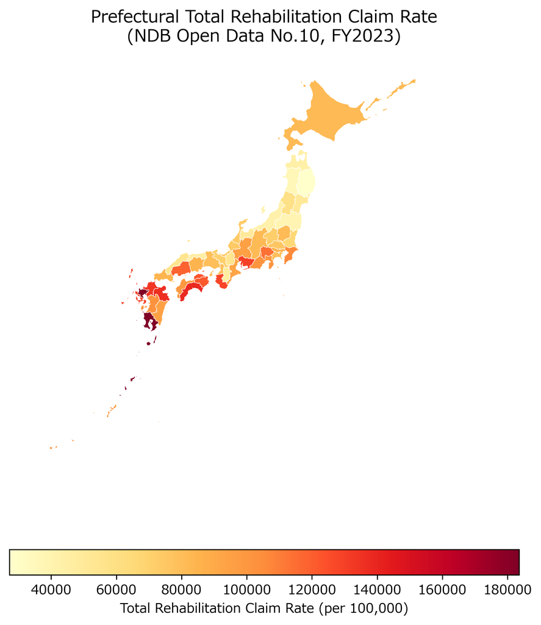

Figure 1. Choropleth map of rehabilitation total claim rates

**Figure 2.** Choropleth map of prefectural hip fracture surgery rates (per 100,000 population), Japan FY2023.

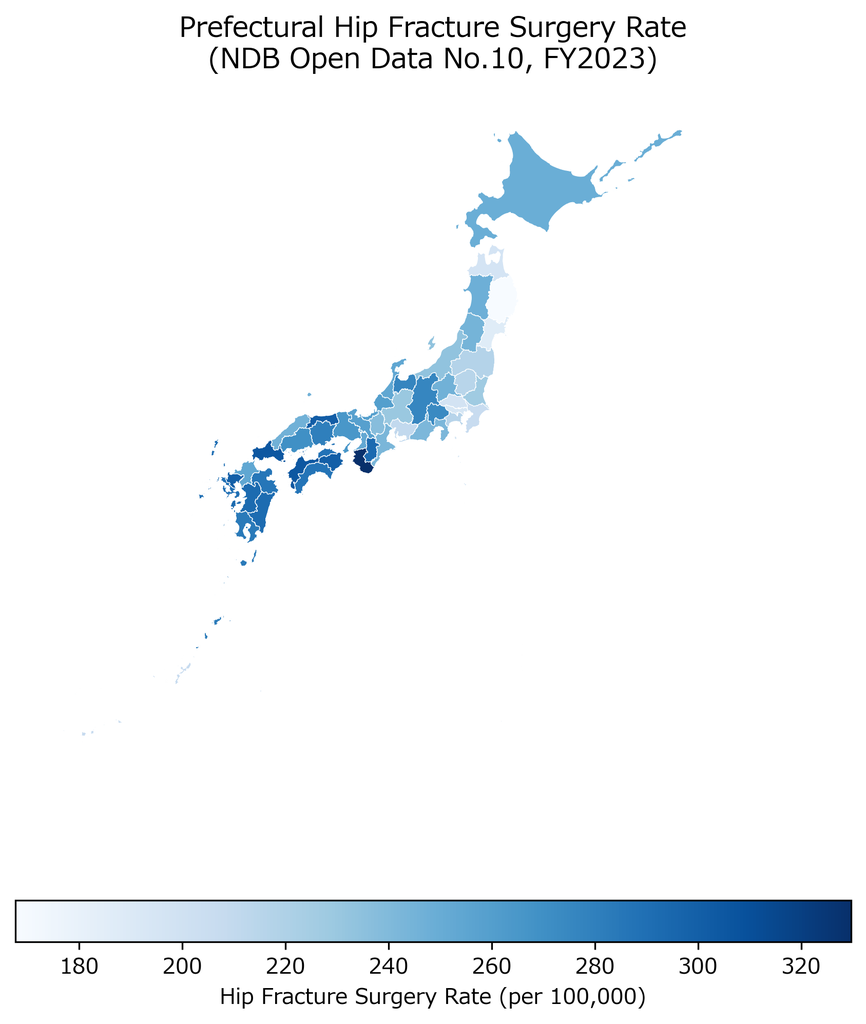

Figure 2. Choropleth map of hip fracture surgery rates

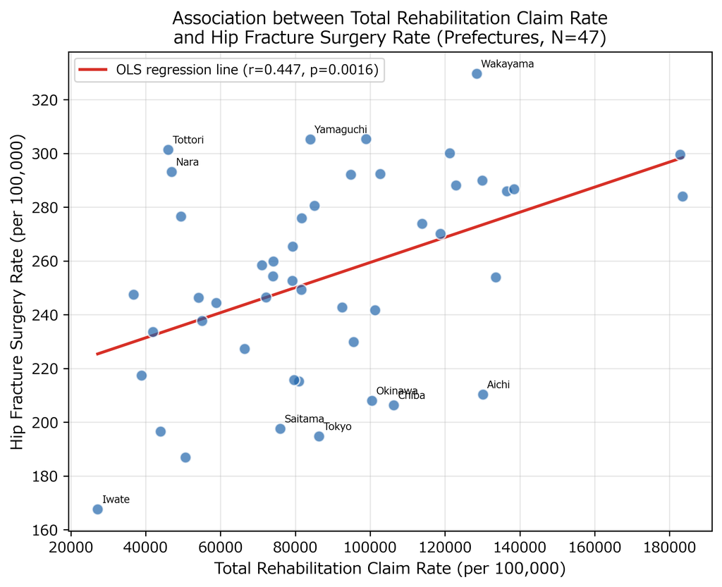

Figure 3. Scatter plot of rehabilitation rate vs hip fracture rate

**Figure 4.** Scatter plot of disuse-syndrome rehabilitation rate (H002) versus hip fracture surgery rate by prefecture (N = 47). Pearson r = 0.344, p = 0.018.

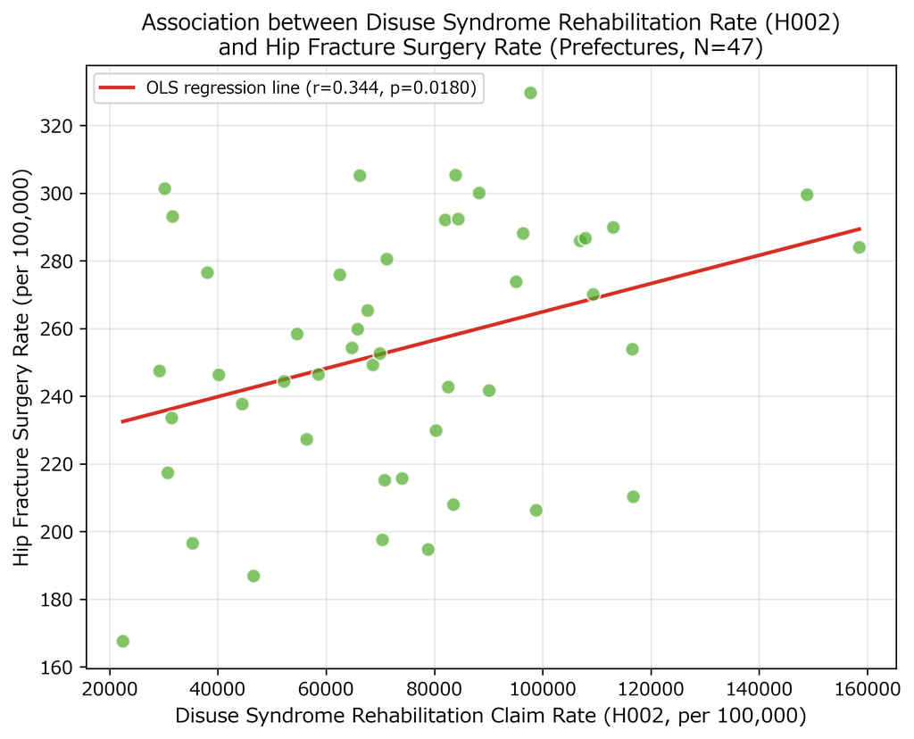

Figure 4. Scatter plot of H002 rate vs hip fracture rate

**Figure 5.** Scatter plot of musculoskeletal rehabilitation rate (H003) versus hip fracture surgery rate by prefecture (N = 47). Pearson r = 0.345, p = 0.018.

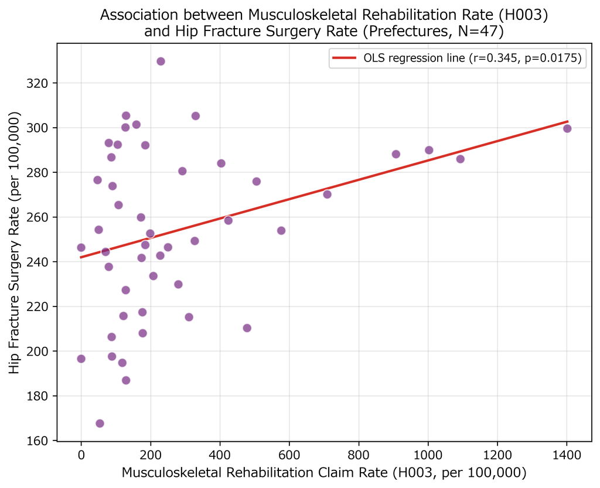

Figure 5. Scatter plot of H003 rate vs hip fracture rate

**Figure 6.** Forest plot of six sensitivity analyses for the primary exposure (rehabilitation total rate) and outcome (hip fracture surgery rate). Red markers indicate p < 0.05; all six specifications are statistically significant.

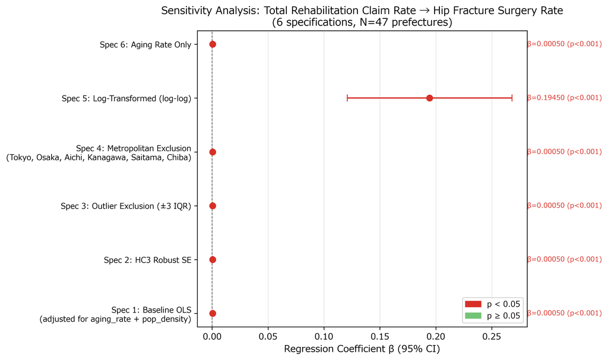

Figure 6. Forest plot of sensitivity analyses

**Figure 7.** Correlation heatmap among key variables (N = 47 prefectures). Cell values are Pearson correlation coefficients.

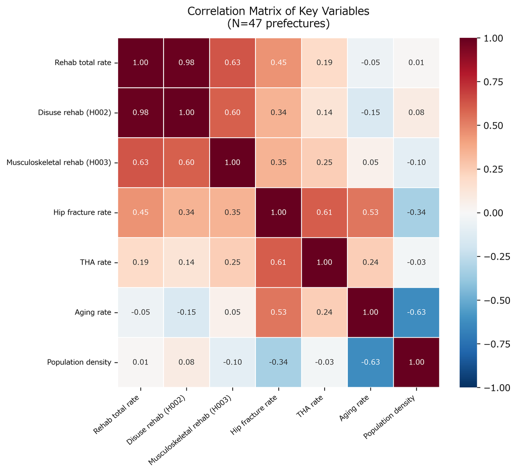

Figure 7. Correlation heatmap